# MEDL_final

**Deep Learning for Mechanical Engineering**  
**Final Exam**  
**June 25th 2020, 6:00 PM to 10:00 PM**

Instructor: Prof. Seungchul Lee  
http://iai.postech.ac.kr/  
Industrial AI Lab at POSTECH

- For your handwritten solution, scan or take a picture of them.
- For your code, only .ipynb file will be graded.
  - Please write your NAME and student ID on your .ipynb files. ex) KangsanLee_20202467_Final.ipynb
- Please compress all the files to make a single .zip file
  - Please write your NAME and student ID on your .zip files. ex) NamjeongLee_20202467_Final.zip
  - Submit it to LMS
- Do not submit a printed version of your code. It will not be graded.
- Please submit your answer sheet on time. No late submission will be allowed.

# Problem 1

Most industries seriously consider their yield rate of production. For this reason, a huge amount of cost is required to control the yield rate. Many industries try to automate inspection process to reduce cost. However, the acquisition data from typical machinery are mostly normal data and seldomly fault data. (generally about less than 5% of normal data)

One way to solve this problem is the 'data generation' method. In this project, we are going to solve the classification problem for imbalanced data by augmenting via the GAN model.

Download data from [here](https://www.dropbox.com/s/k6wqyq2asi92z8x/MNIST_one_seven_imbalanced%20_data.zip?dl=1).

- data format: pkl
- the number of data:
  - one: 6000
  - seven: 300

Note: strongly recommend you to use GPU rather than CPU. (you can use Colab GPU for free)

```python
import numpy as np
import matplotlib.pyplot as plt
from six.moves import cPickle
import tensorflow as tf
```

(1) Load and preprocess data.

**Step 1**: load

- one.pkl
- seven.pkl

**Step 2**: convert the loaded data to a binary image

**Step 3**: split into train/test dataset

- `one` train index: 0~999
- `one` test index: 1000~6000
- `seven` train index: 0~4 (only five images)
- `seven` test index: 5~300

**Step 4**: labeling

- one-hot encoding

**Step 5**: batchmaker

- train and test batchmakers

```python
# your code here
```

(2) Conduct the binary classification by convolution neural network (CNN) model.

**Structure**

- First convolution layer
  - filter size: $3\times 3$
  - channel: $32$
  - max pooling: $2\times 2$
- Second convolution layer
  - filter size: $3\times 3$
  - channel: $64$
  - max pooling: $2\times 2$
- Nonlinear activation: ReLu

**Model Training**

- Optimizer: AdamOptimizer
- Learning rate: $0.0001$
- Max iter: $2500$

**Model Test**

- radom image test
- `one` image test
- `seven` image test
- you should calculate the test accuracy

```python
# Random image test
# your code here
```

```
Accuracy : 98.82%
```

```python
# One image test
# your code here
```

```
Accuracy : 100.0%
```

```python
# Seven image test
# your code here
```

```
Accuracy : 80.33898305084746%
```

(3) As you can see, the accuracy is low for images of `seven`. We would like to generate more images of `seven` by a GAN model to overcome the data imbalance problem. In this problem you should use convolutional layers instead of ANN layer for both a generator and a discriminator.

**Generator**: deconvolution layer (= `conv2d_transpose`)

- Input layer: 100
- First deconvolution layer
  - filter size: $7\times 7$
  - channel: $64$
  - stride: $(1,1)$
  - padding: 'VALID'
- Second deconvolution layer:
  - filter size: $4\times 4$
  - channel: $32$
  - stride: $(2,2)$
  - padding: 'SAME'
- Third deconvolution layer
  - filter size: $4\times 4$
  - channel: $1$
  - stride: $(2,2)$
  - pading: 'SAME'

**Discriminator**: convolution layer

- Input layer: $28\times 28 \times 1$
- First convolution layer
  - filter size: $3\times 3$
  - channel: $32$
  - padding: 'SAME'
- Second convolution layer
  - filter size: $3\times 3$
  - channel: $64$
  - padding: 'SAME'
- no pooling layer

**Training**

- D_LR: 0.00004
- G_LR: 0.00008
- Max iteration: 5500
- Optimizer: AdamOptimizer

**Generated Images**

- Convert generated image to binary image
- original `one` images: original `seven` images + generated fake `seven` images = 1:1

```
Epoch: 0000 D_loss: 1.589 G_loss: 0.5877
```

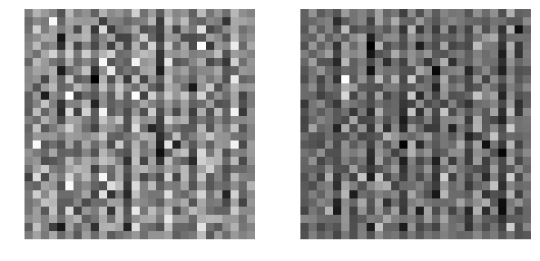

```
Epoch: 1500 D_loss: 0.07148 G_loss: 3.753
```

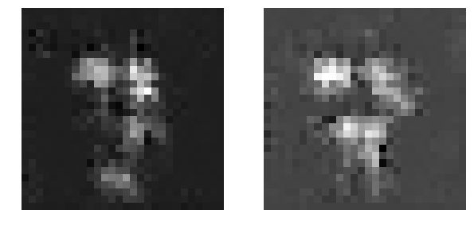

```
Epoch: 3000 D_loss: 0.02628 G_loss: 4.937
```

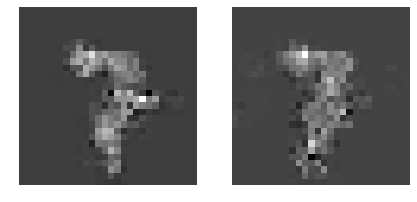

```
Epoch: 4500 D_loss: 0.00668 G_loss: 6.563
```

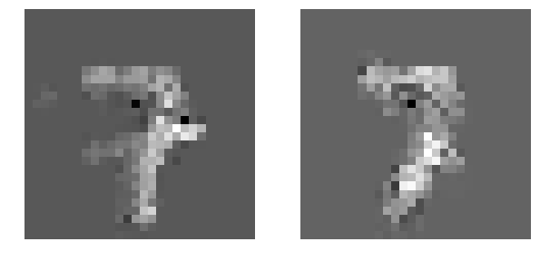

```python
# your code here
```

```python
# generated data
# your code here
```

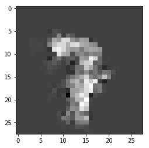

```python
# plot random generated data
# your code here
```

```python
# convert generated image to binary (this converted images will be used for further analysis)
# your code here
```

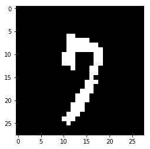

```python
# plot random converted image
# your code here
```

(4) Train the CNN model again using the original and generated (or augmented) data.

- stack the generated data and original train data of `seven`
- define new train data by putting new `seven` train and `one` train data altogether
- define new train label
- use the same CNN structure
- test
  - random image test
  - one image test
  - seven image test

```python
# your code here
```

```python
# random image test
# your code here
```

```
Accuracy : 99.51%
```

```python
# one image test
# your code here
```

```
Accuracy : 99.98%
```

```python
# seven image test
# your code here
```

```
Accuracy : 91.18644067796609%
```

# Problem 2

- In this problem, we have bearing data with 3 classes (healthy, inner fault, outer fault).
- The objective is to classify the given data using state-of-the-art deep learning models.
- You will build and test a deep learning model.

### Download & Load Data

We already made the data ready for you. You can download the data in .npy format. Six files are prepared for a [train set](https://www.dropbox.com/s/w0aq3zwoujw41u5/bearing_train.zip?dl=1) and three files for a [test set](https://www.dropbox.com/s/0mqrn3tr7i3nala/bearing_test.zip?dl=1).

- Healty_train_1.npy
- Healty_train_2.npy
- InnerFault_train_1.npy
- InnerFault_train_2.npy
- OuterFault_train_1.npy
- OuterFault_train_2.npy
- Healty_test.npy
- InnerFault_test.npy
- OuterFault_test.npy

(1) Plot all data with the title of its filename.

```python
import tensorflow as tf
import numpy as np
import os
import matplotlib.pyplot as plt
%matplotlib inline
```

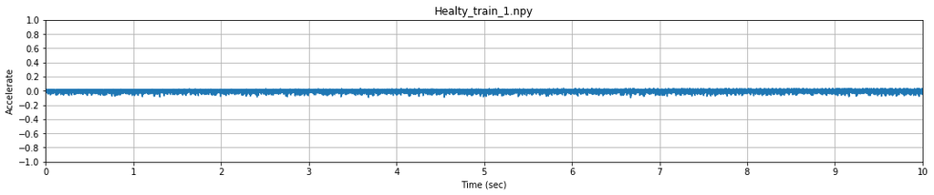

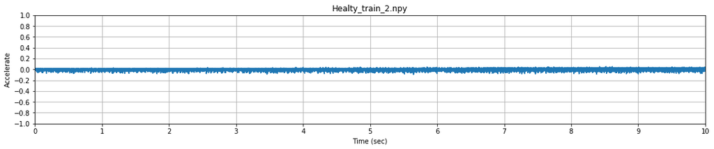

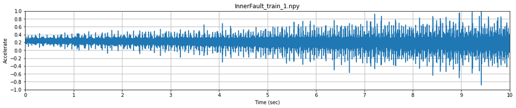

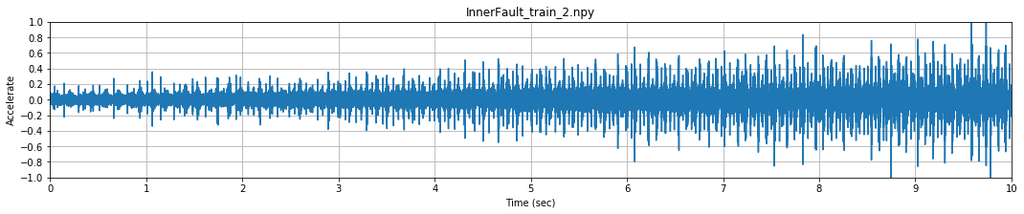

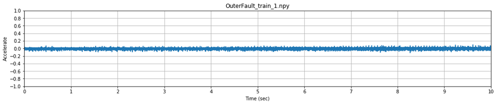

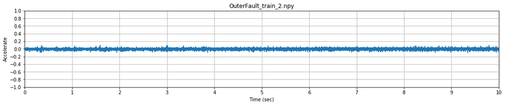

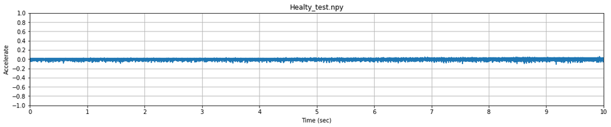

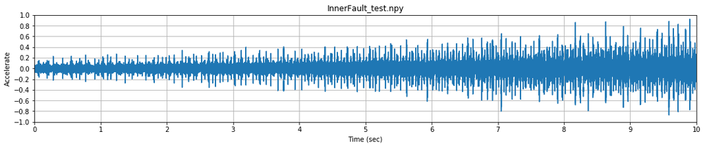

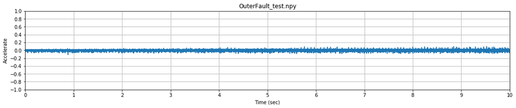

```python
# Your code here
```

In the following subproblems, you will be introduced deep learning models which are used for time-series data classification. You are asked to build the model with the given architecture and evaluate the performance.

### Various deep learning models for time-series data classification

*"Deep Learning Algorithms for Bearing Fault Diagnostics – A Comprehensive Review", 2020, S Zhang et al.*

### Implementation of CNN-LSTM model

You will use the 1D convolution layer for this problem. We have learned 2D convolution in class and 1D convolution is nothing but 2D convolution with a height as 1. Get help from the below links.

- [tf.layers.conv1d](https://www.tensorflow.org/versions/r1.15/api_docs/python/tf/layers/conv1d)
- [tf.layers.conv2d](https://www.tensorflow.org/versions/r1.15/api_docs/python/tf/layers/conv2d)
- etc.

```python
# Your code here
# tf.layers.conv1d is used in this case, but you do not have to.


# you do not have to print the model out like below
```

[output not shown]

```
Model: "model"
_________________________________________________________________
Layer (type)                 Output Shape              Param #
=================================================================
input_1 (InputLayer)         [(None, 1600)]            0
_________________________________________________________________
reshape (Reshape)            (None, 80, 20)            0
_________________________________________________________________
conv1d (Conv1D)              (None, 80, 32)            40992
_________________________________________________________________
max_pooling1d (MaxPooling1D) (None, 40, 32)            0
_________________________________________________________________
re_lu (ReLU)                 (None, 40, 32)            0
_________________________________________________________________
dropout (Dropout)            (None, 40, 32)            0
_________________________________________________________________
lstm (LSTM)                  (None, 128)               82432
_________________________________________________________________
dense (Dense)                (None, 3)                 387
_________________________________________________________________
softmax (Softmax)            (None, 3)                 0
=================================================================
Total params: 123,811
Trainable params: 123,811
Non-trainable params: 0
_________________________________________________________________
```

(3) Create trainset and testset to feed the model you designed. Set the number of segments equals to 4,000 for trainset and 1,000 for testset (for each class).

```python
# Your code here
```

```
(12000, 1600) (12000, 3) (3000, 1600) (3000, 3)
```

(4) Plot a random segment for both trainset and testset.  
Hint: Reshape the segment into (1600, ) if necessary.

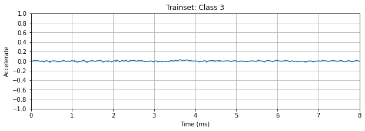

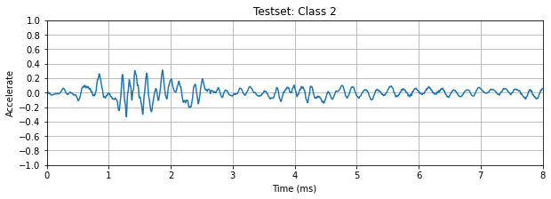

```python
# Your code here
```

(5) Train the model and print the training procedure.

```python
# Your code here


# you do not have to print out the results like below
```

[output not shown]

```
Train on 12000 samples, validate on 3000 samples
```

[output not shown]

```
<tensorflow.python.keras.callbacks.History at 0x1515b76d5b70>
```

(6) Evaluate the model in terms of accuracy of the testset.

```python
# Your code here


# print out the model accuracy, but you do not have to print it out like below
```

[output not shown]